# KTI_DESeq2_TC_OCRP_Analysis

Vishnu Ramasubramanian

2025-02-05

# Setup

Load necessary libraries and set global options.

# Data Preparation

Load R workspace containing count data and meta information. Filter out samples that are not relevant for this analysis and prepare table with meta info.

```r
# Set working directory to the specified project folder
setwd("C:/Users/ivanv/Desktop/UMN_Projects/Ritesh_DESeq_Analysis/KTI_MS_RNASeqAnalysis/")

# Load the dataset

load("KTI_DESeq2_TC_Analysis_Data.RData")

### Remove BBI and 7s samples from data to retain KTI and Bert samples

BBI7sInd <- grep("BB1|7s",colnames(Dat_Sub_Filt))
dat_Sub1_Filt <- Dat_Sub_Filt[,-BBI7sInd]
dat_Filt <- dat_Sub1_Filt

### factor names

factNames_Filt <- colnames(dat_Filt)
factNamesSplt_Filt <- lapply(factNames_Filt,function(x) strsplit(x,"-"))
factNamesLevels_Filt <- unlist(lapply(factNamesSplt_Filt,function(x)paste(x[[1]][1],x[[1]][2],x[[1]][3],sep="-")))

stageNamesLevels_Filt <- unlist(lapply(factNamesSplt_Filt,function(x)paste(x[[1]][1],x[[1]][2],sep="-")))
mutNamesLevels_Filt <- unlist(lapply(factNamesSplt_Filt,function(x) x[[1]][3]))

####

conditionFilt <- factor(factNamesLevels_Filt)
conditionFilt <- gsub("-","_",conditionFilt)
conditionFilt <- as.factor(conditionFilt)
conditionFilt =relevel(conditionFilt,ref = "R5_1_Bert")

####
stageFilt <- factor(stageNamesLevels_Filt)
stageFilt <- gsub("-","_",stageFilt)
stageFilt <- as.factor(stageFilt)
stageFilt =relevel(stageFilt,ref = "R5_1")
###
mutFilt <- factor(mutNamesLevels_Filt)
mutFilt <- as.factor(mutFilt)
genoFilt =relevel(mutFilt,ref = "Bert")

###

coldataFilt <- data.frame(row.names=colnames(dat_Filt),conditionFilt,stageFilt,genoFilt)
colnames(coldataFilt) <- c("Condition","Stage","Genotype")
head(coldataFilt)
```

```
##             Condition Stage Genotype
## R5-1-Bert-3 R5_1_Bert  R5_1     Bert
## R5-1-Bert-4 R5_1_Bert  R5_1     Bert
## R5-1-KTI-1   R5_1_KTI  R5_1      KTI
## R5-1-KTI-3   R5_1_KTI  R5_1      KTI
## R5-2-Bert-1 R5_2_Bert  R5_2     Bert
## R5-2-Bert-2 R5_2_Bert  R5_2     Bert
```

```r
rownames(dat_Filt) <- gsub(".Wm82.a4.v1","",rownames(dat_Filt))
dat_Filt <- apply(dat_Filt,2,function(x) round(x,digits=0))
```

# DESeq2 Analysis

Create DESeq data from count data matrix and set design to ‘Genotype + Stage + Genotype:Stage’ to specify the full model. DESeq function encompasses several steps in model fitting and testing and calls sub-functions to perform the following steps:

1. estimation of size factors,
2. estimation of dispersions,
3. calculation of gene-wise dispersion estimates,
4. estimation of mean-dispersion relationship,
5. adjustment of dispersion estimates to get final dispersion estimates,
6. model fitting and performance of statistical tests.

```r
# Filter the data for specific conditions and create a new column

dds_Filt <- DESeqDataSetFromMatrix(countData = dat_Filt, colData = coldataFilt,design=~ Genotype+Stage+Genotype:Stage)
ddsFilt <- DESeq(dds_Filt)
ddsFilt
```

```
## class: DESeqDataSet
## dim: 52872 20
## metadata(1): version
## assays(4): counts mu H cooks
## rownames(52872): Glyma.01G000100 Glyma.01G000137 ... Glyma.U005100
##   Glyma.U005200
## rowData names(54): baseMean baseVar ... deviance maxCooks
## colnames(20): R5-1-Bert-3 R5-1-Bert-4 ... R6-2-KTI-2 R6-2-KTI-3
## colData names(4): Condition Stage Genotype sizeFactor
```

## Data Visualization

Visualization of dispersion estimates from the model

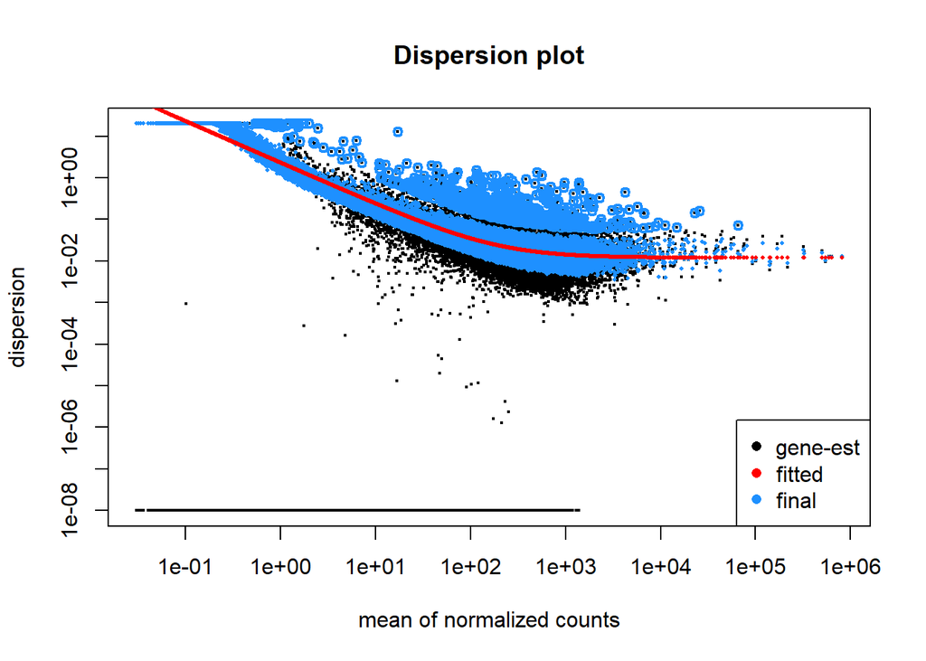

```r
# Plot Dispersions:
# png(paste("AllStages-qc-Filt-dispersions-OCRP.png",sep=""), 1000, 1000, pointsize=20)
# plotDispEsts(ddsFilt, main="Dispersion plot")
# dev.off()

plotDispEsts(ddsFilt, main="Dispersion plot")
```

Black points correspond to gene-wise dispersion estimates plotted against normalized mean counts. Red points correspond to the fitted values from the model. Blue points correspond to final shrunken estimates and those black points circled in blue corresponds to those points that were not shrunk towards the fitted values. For detailed interpretation see here.

### log transformation of filtered DESeq data

```r
# Regularized log transformation for clustering/heatmaps, etc
rldFilt <- rlogTransformation(ddsFilt)
head(assay(rldFilt))
```

```
##                 R5-1-Bert-3 R5-1-Bert-4 R5-1-KTI-1 R5-1-KTI-3 R5-2-Bert-1
## Glyma.01G000100    5.960513    5.608419   6.071980   5.763812    5.792699
## Glyma.01G000137    5.240019    5.103982   5.190770   5.216214    5.180431
## Glyma.01G000174    6.072991    6.030008   5.795840   5.946187    5.863363
## Glyma.01G000211    7.342620    7.277959   7.265613   7.246841    7.411307
## Glyma.01G000248    5.081531    5.048853   5.213927   5.064342    5.034566
## Glyma.01G000285    5.314129    5.054011   5.199668   4.653552    5.235791
##                 R5-2-Bert-2 R5-2-KTI-2 R5-2-KTI-3 R5-3-Bert-2 R5-3-Bert-3
## Glyma.01G000100    6.109132   5.733711   5.752002    6.388976    6.405121
## Glyma.01G000137    5.413079   5.334337   5.004966    5.818357    5.642132
## Glyma.01G000174    6.214168   5.878849   5.835968    6.442639    6.461982
## Glyma.01G000211    7.506157   7.027868   6.979622    7.562444    7.694597
## Glyma.01G000248    5.284071   4.896897   4.905573    5.525857    5.372656
## Glyma.01G000285    5.395071   4.981569   4.920291    5.221126    5.538246
##                 R5-3-KTI-1 R5-3-KTI-2 R6-1-Bert-1 R6-1-Bert-2 R6-1-KTI-3
## Glyma.01G000100   6.052851   5.794289    5.931978    5.522704   5.798395
## Glyma.01G000137   5.219417   5.412133    5.583394    4.979137   5.305187
## Glyma.01G000174   5.747916   5.951057    6.095835    5.575286   6.089878
## Glyma.01G000211   7.464608   7.299846    7.450943    7.250241   7.290494
## Glyma.01G000248   5.103272   4.937420    5.133040    4.834589   5.010345
## Glyma.01G000285   5.075272   5.087652    5.304051    4.943749   5.473016
##                 R6-1-KTI-4 R6-2-Bert-2 R6-2-Bert-3 R6-2-KTI-2 R6-2-KTI-3
## Glyma.01G000100   5.532202    6.154958    5.591550   6.178857   6.182587
## Glyma.01G000137   4.836788    5.262187    4.718407   5.320129   5.291727
## Glyma.01G000174   5.811946    6.040750    5.662470   6.307663   6.204478
## Glyma.01G000211   6.987526    7.487156    6.806293   7.697376   7.680416
## Glyma.01G000248   4.725150    5.267796    4.637770   5.504445   5.419635
## Glyma.01G000285   4.834051    5.199833    4.915563   5.660820   5.655917
```

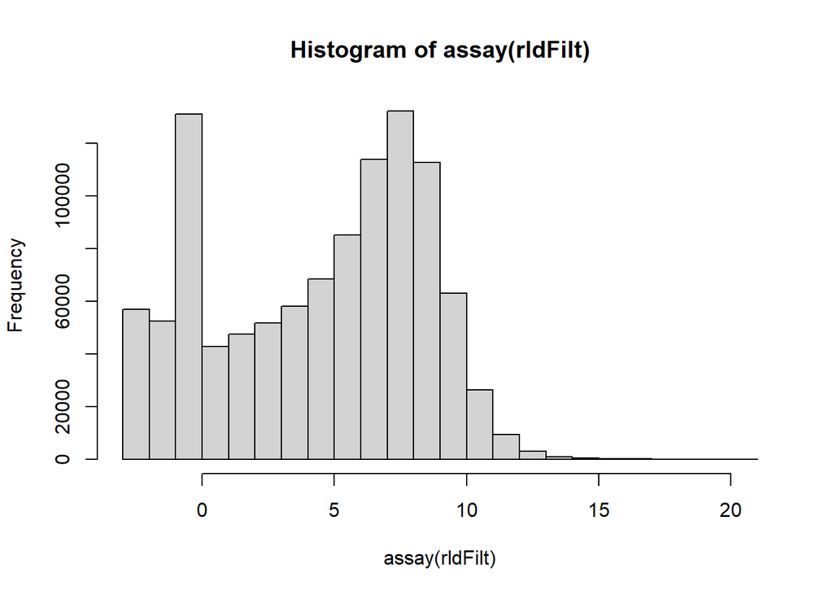

```r
hist(assay(rldFilt))
```

### PCA plots

Visualize clustering of sample sub-groups based on genotype, stage and combinations of genotype and stage.

```
## using ntop=500 top features by variance
```

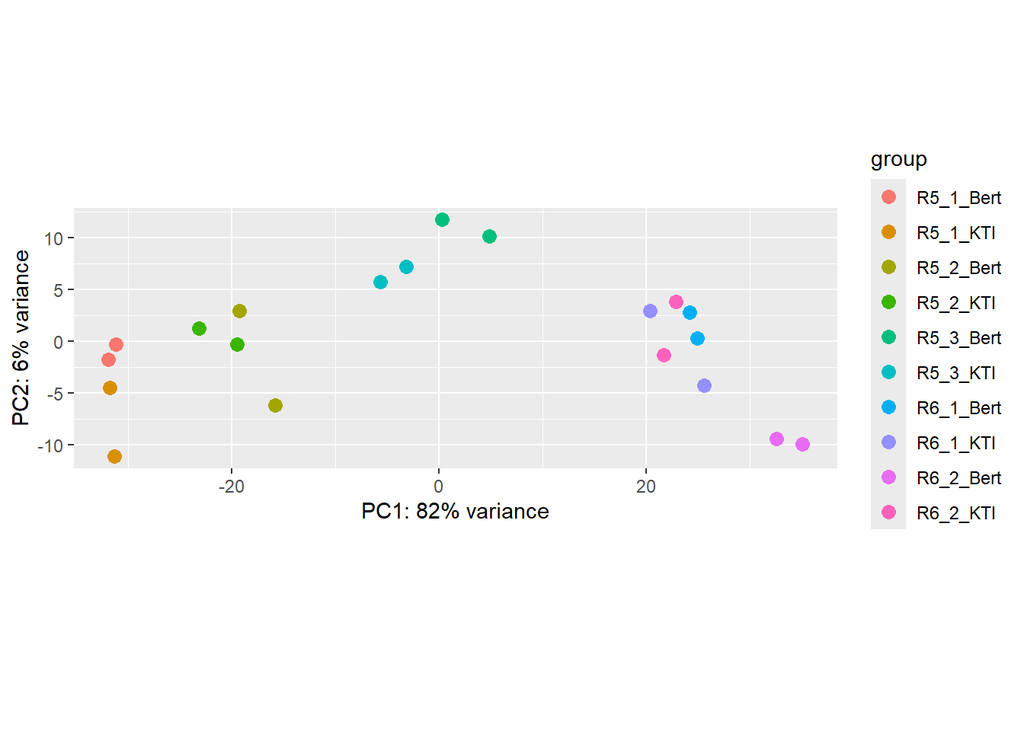

```r
### PCA on samples grouped on combinations of genotype and stage

plotPCA(rldFilt,intgroup="Condition")
```

```
## using ntop=500 top features by variance
```

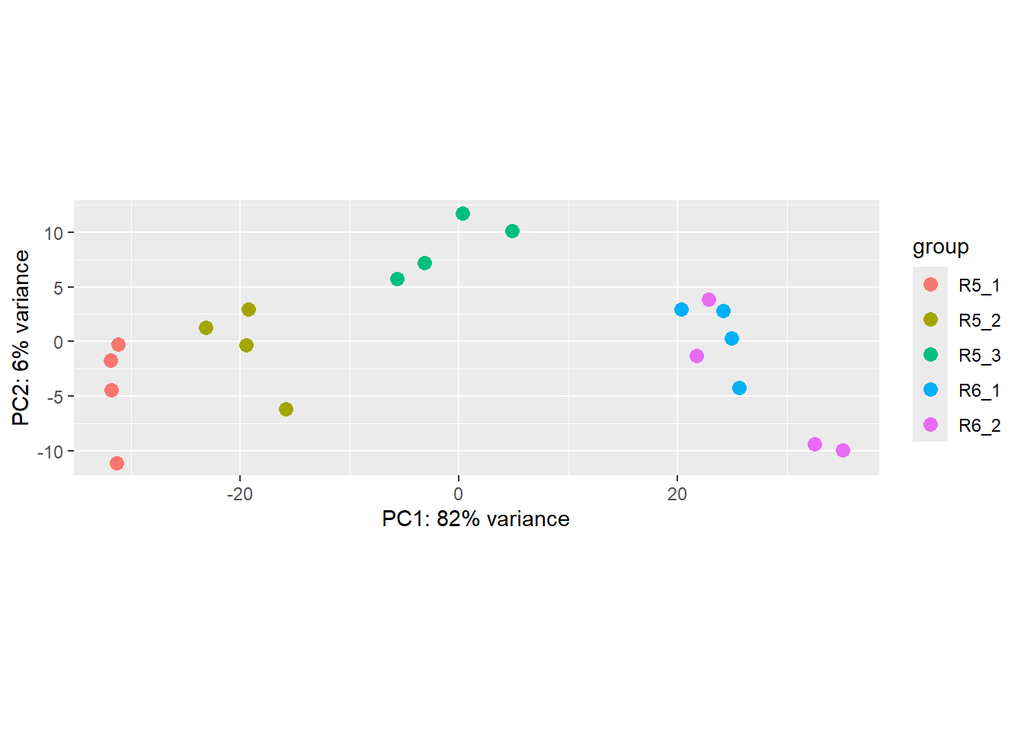

```r
### PCA on samples grouped on stage

plotPCA(rldFilt,intgroup="Stage")
```

```
## using ntop=500 top features by variance
```

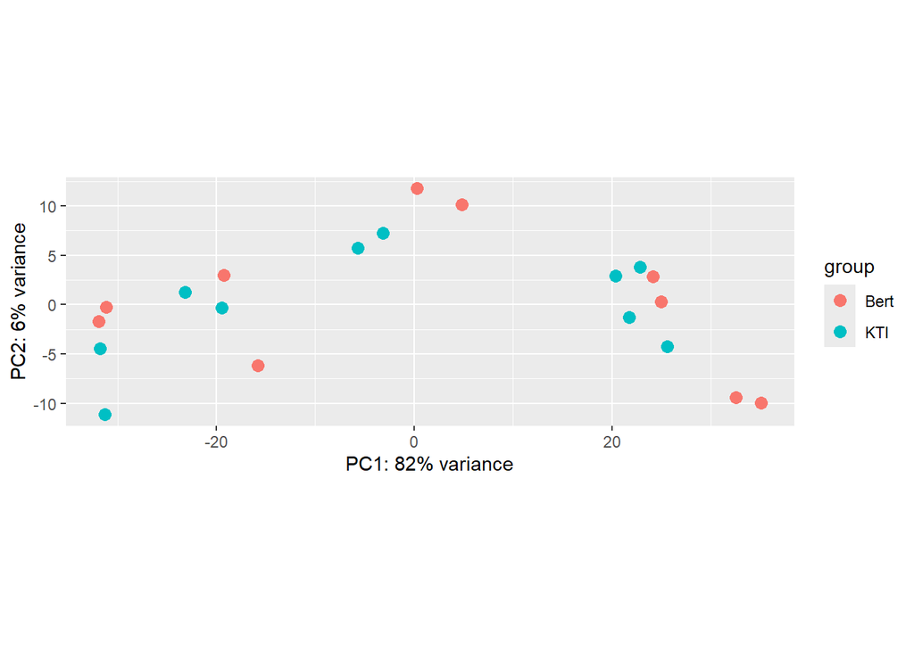

```r
### PCA on samples grouped on genotype

plotPCA(rldFilt,intgroup="Genotype")
```

```r
# R6-2 KTI is closer to R6-1 KTI/Bert than R6-2 Bert (otherwise, the samples cluster separately according to stages)


# Principal Components Analysis (PCA) based on conditions

# png(paste("AllStages-qc-Filt-PCA-OCRP.png",sep=""), 1000, 1000, pointsize=20)
# plotPCA(rldFilt,intgroup="Condition")
# dev.off()

# Principal Components Analysis based on stages
# png(paste("AllStages-qc-Filt-PCA_Stages-OCRP.png",sep=""), 1000, 1000, pointsize=20)
# plotPCA(rldFilt,intgroup="Stage")
# dev.off()

# Principal Components Analysis based on genotype
# png(paste("AllStages-qc-Filt-PCA_Genotypes-OCRP.png",sep=""), 1000, 1000, pointsize=20)
# plotPCA(rldFilt,intgroup="Genotype")
# dev.off()
```

#### Heatmap of assay sample distance

```r
## Use RColorBrewer, better
library(RColorBrewer)
(mycols <- brewer.pal(8, "Dark2")[1:length(unique(conditionFilt))])
```

```
##  [1] "#1B9E77" "#D95F02" "#7570B3" "#E7298A" "#66A61E" "#E6AB02" "#A6761D"
##  [8] "#666666" NA        NA
```

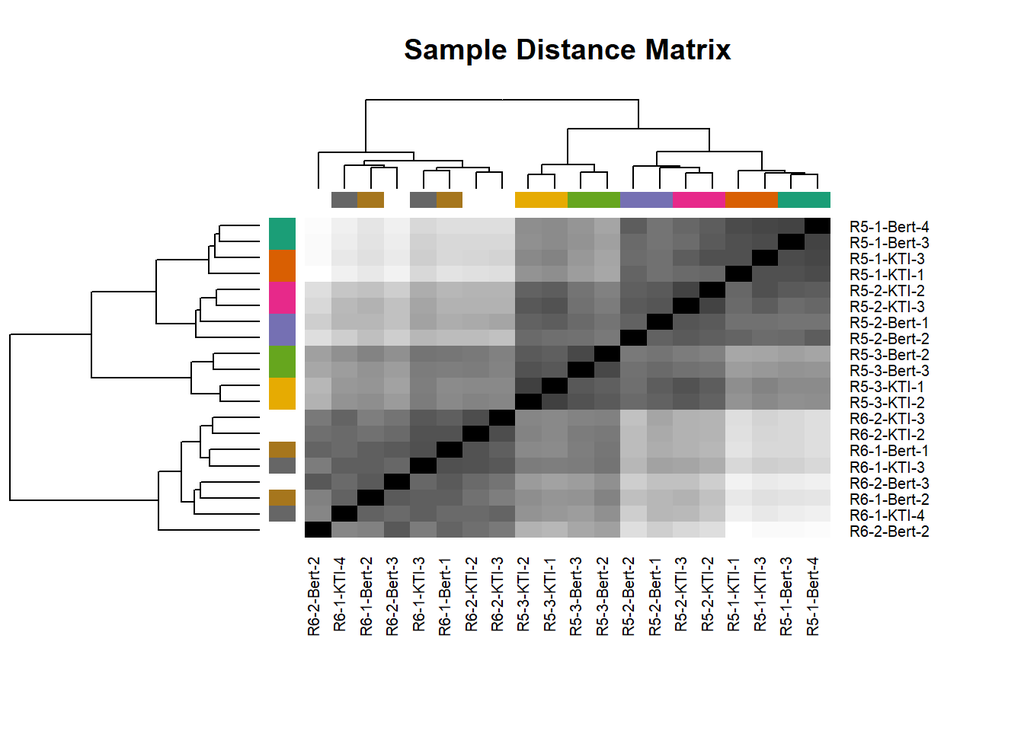

```r
# Sample distance heatmap
# Convert count data to a matrix format (required for DESeq2)
sampleDistsFilt <- as.matrix(dist(t(assay(rldFilt))))
library(gplots)
heatmap.2(as.matrix(sampleDistsFilt), key=F, trace="none",
          col=colorpanel(100, "black", "white"),
          ColSideColors=mycols[conditionFilt], RowSideColors=mycols[conditionFilt],
          margin=c(10, 10), main="Sample Distance Matrix")
```

```r
# png(paste("AllStages_qc_Filt_2-heatmap-samples-OCRP.png"), w=1000, h=1000, pointsize=20)
# Convert count data to a matrix format (required for DESeq2)
heatmap.2(as.matrix(sampleDistsFilt), key=F, trace="none",
          col=colorpanel(100, "black", "white"),
          ColSideColors=mycols[conditionFilt], RowSideColors=mycols[conditionFilt],
          margin=c(10, 10), main="Sample Distance Matrix")
#dev.off()


######
```

## DE Analysis

```r
      contrastNames <- resultsNames(ddsFilt)[-1]

      resFilt_List <- list()
      res_List <- list()

      for(nCn in 1:length(contrastNames)){
        res <- results(ddsFilt ,contrast=list(c(contrastNames[nCn]),character()))
        res <- res[order(res$padj),]
        resFilt <- res[which(res$padj<0.05),]

          resFilt_List[[nCn]] <- resFilt
        res_List[[nCn]] <- res

        resMod <- cbind.data.frame(rownames(res),res)
        resFiltMod <- cbind.data.frame(rownames(resFilt),resFilt)

            colnames(resMod) <- paste(colnames(resMod),".",contrastNames[nCn],sep="")
            colnames(resFiltMod) <- paste(colnames(resFiltMod),".",contrastNames[nCn],sep="")

        colnames(resMod)[1] <- "GeneID"
        colnames(resFiltMod)[1] <- "GeneID"


        if(nCn==1){
          ResS_Comb <- resMod
          ResSFilt_Comb <- resFiltMod
        }else if(nCn>1){
          ResS_Comb <- merge(ResS_Comb,resMod,by="GeneID",all=TRUE)
          ResSFilt_Comb <- merge(ResSFilt_Comb,resFiltMod,by="GeneID",all=TRUE)
        }

      }

      countsData <- as.data.frame(counts(ddsFilt, normalized=TRUE))
      countsDataMod <- cbind.data.frame(rownames(countsData),countsData)
      colnames(countsDataMod)[1] <- "GeneID"

      ResS_Comb_Data <- merge(as.data.frame(ResS_Comb),countsDataMod , by="GeneID", sort=FALSE)


      write.csv(ResS_Comb_Data, file=paste("All_Stages_diffexpr-results_KTIContrast_OCRP.csv",sep=""),quote = FALSE,row.names = F)
      write.csv(ResSFilt_Comb, file=paste("All_Stages_Filt_p05_diffexpr-results_KTIContrast_OCRP.csv",sep=""),quote = FALSE,row.names = F)
```

### LRT Analysis to isolate genotype x stage interaction

In DESeq, a Likelihood Ratio Test (LRT) can be performed by constructing a reduced model from a full model and specifying the test as ‘LRT’

```r
## LRT using a reduced model

  ddsFiltRed <- DESeq(ddsFilt,test="LRT",reduced = ~Genotype+Stage)
```

```
## found already estimated dispersions, replacing these
```

### Extract results from LRT for specific contrasts and filter based on adjusted p.value cutoff.

For this analysis, a p.adj value of 0.01 was used, resulting in a set of 377 genes.

```r
  resIRed <- results(ddsFiltRed,contrast=list(c("GenotypeKTI.StageR6_1","GenotypeKTI.StageR6_2")))

## Contrasts from full model

  resIFull_Main_6_2 <- results(ddsFilt,contrast=list(c("Genotype_KTI_vs_Bert","Stage_R6_2_vs_R5_1","GenotypeKTI.StageR6_2")))
###

    resIFull6_2 <- results(ddsFilt,contrast=list(c("GenotypeKTI.StageR6_2")))
    resIFull6_1 <- results(ddsFilt,contrast=list(c("GenotypeKTI.StageR6_1")))


  resIFull6_2 <- resIFull6_2[order(resIFull6_2$padj),]
    resIFull6_1 <- resIFull6_1[order(resIFull6_1$padj),]

    resIFull <- results(ddsFilt,contrast=list(c("GenotypeKTI.StageR6_1","GenotypeKTI.StageR6_2")))



### p - 0.01

    padj_cutoff <- 0.01

##
    resIRed <- resIRed[order(resIRed$padj),]
  resIRedFilt <- resIRed[which(resIRed$padj<padj_cutoff),]

##

    resIRed_GIDS <- rownames(resIRedFilt)

    resIFull <- resIFull[order(resIFull$padj),]

    resIRed_FC <- resIRedFilt$log2FoldChange
    names(resIRed_FC) <- rownames(resIRedFilt)


  resIFull4RedIDs_Ind <- which(rownames(resIFull) %in% resIRed_GIDS)
    resIFull4RedIDs_Filt <- resIFull[resIFull4RedIDs_Ind,]

#### resIFull

    resIFull_FC <- resIFull$log2FoldChange[which(rownames(resIFull) %in% resIRed_GIDS)]
    names(resIFull_FC) <- resIRed_GIDS


    head(assay(rldFilt))
```

```
##                 R5-1-Bert-3 R5-1-Bert-4 R5-1-KTI-1 R5-1-KTI-3 R5-2-Bert-1
## Glyma.01G000100    5.960513    5.608419   6.071980   5.763812    5.792699
## Glyma.01G000137    5.240019    5.103982   5.190770   5.216214    5.180431
## Glyma.01G000174    6.072991    6.030008   5.795840   5.946187    5.863363
## Glyma.01G000211    7.342620    7.277959   7.265613   7.246841    7.411307
## Glyma.01G000248    5.081531    5.048853   5.213927   5.064342    5.034566
## Glyma.01G000285    5.314129    5.054011   5.199668   4.653552    5.235791
##                 R5-2-Bert-2 R5-2-KTI-2 R5-2-KTI-3 R5-3-Bert-2 R5-3-Bert-3
## Glyma.01G000100    6.109132   5.733711   5.752002    6.388976    6.405121
## Glyma.01G000137    5.413079   5.334337   5.004966    5.818357    5.642132
## Glyma.01G000174    6.214168   5.878849   5.835968    6.442639    6.461982
## Glyma.01G000211    7.506157   7.027868   6.979622    7.562444    7.694597
## Glyma.01G000248    5.284071   4.896897   4.905573    5.525857    5.372656
## Glyma.01G000285    5.395071   4.981569   4.920291    5.221126    5.538246
##                 R5-3-KTI-1 R5-3-KTI-2 R6-1-Bert-1 R6-1-Bert-2 R6-1-KTI-3
## Glyma.01G000100   6.052851   5.794289    5.931978    5.522704   5.798395
## Glyma.01G000137   5.219417   5.412133    5.583394    4.979137   5.305187
## Glyma.01G000174   5.747916   5.951057    6.095835    5.575286   6.089878
## Glyma.01G000211   7.464608   7.299846    7.450943    7.250241   7.290494
## Glyma.01G000248   5.103272   4.937420    5.133040    4.834589   5.010345
## Glyma.01G000285   5.075272   5.087652    5.304051    4.943749   5.473016
##                 R6-1-KTI-4 R6-2-Bert-2 R6-2-Bert-3 R6-2-KTI-2 R6-2-KTI-3
## Glyma.01G000100   5.532202    6.154958    5.591550   6.178857   6.182587
## Glyma.01G000137   4.836788    5.262187    4.718407   5.320129   5.291727
## Glyma.01G000174   5.811946    6.040750    5.662470   6.307663   6.204478
## Glyma.01G000211   6.987526    7.487156    6.806293   7.697376   7.680416
## Glyma.01G000248   4.725150    5.267796    4.637770   5.504445   5.419635
## Glyma.01G000285   4.834051    5.199833    4.915563   5.660820   5.655917
```

```r
  rldFilt_IRed <- assay(rldFilt)[which(rownames(assay(rldFilt)) %in% resIRed_GIDS),]
  mat <- rldFilt_IRed
    mat <- mat - rowMeans(mat)
```

## DEG Patterns Analysis

For an input expression matrix and metadata, degpatterns identifies clusters of genes based on their differential gene expression patter across the time variable like ‘stage’ and a grouping variable such as ‘genotype’. Another important parameter is ‘minc’ which specifies the minimum number of genes in a cluster.

```r
### Cluster using degPatterns

clusters3 <- degPatterns(mat, metadata = coldataFilt, time = "Stage", col="Genotype",minc=5)
```

```
## Working with 377 genes.
```

```
## Working with 362 genes after filtering: minc > 5
```

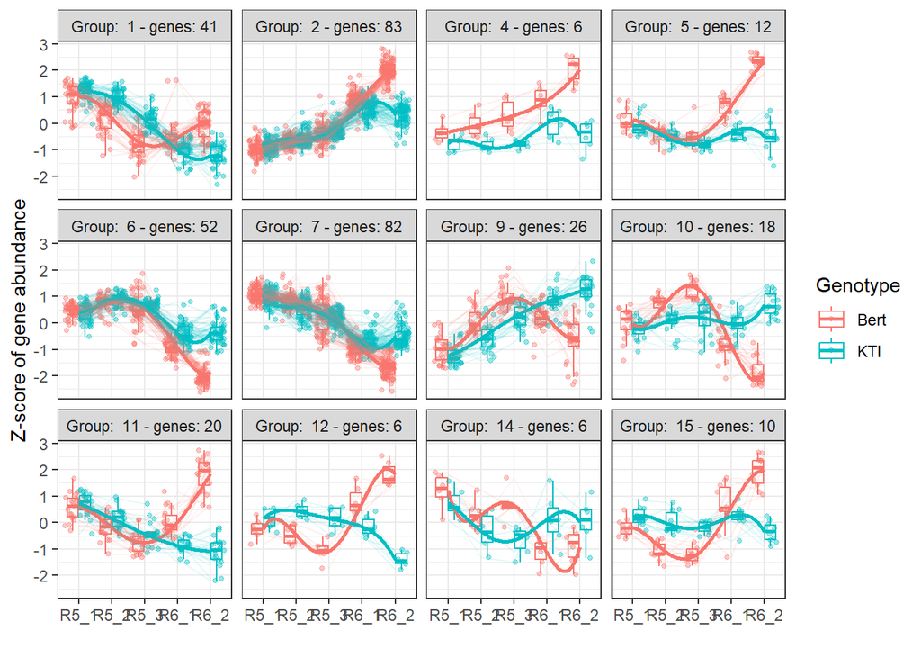

```r
capwords <- function(s, strict = FALSE) {
    cap <- function(s) paste(toupper(substring(s, 1, 1)),
                  {s <- substring(s, 2); if(strict) tolower(s) else s},
                             sep = "", collapse = " " )
    sapply(strsplit(s, split = " "), cap, USE.NAMES = !is.null(names(s)))
}

### AnntnTab

AnntnTab <- read.csv("Annotation_AllGenes.csv",header=T)
colnames(AnntnTab)[1] <- "GeneID"
AnntnTab[,"GeneID"] <- capwords(tolower(AnntnTab[,"GeneID"]))


resIRedFilt_DF <-  as.data.frame(resIRedFilt)
rownames(resIRedFilt_DF) <- capwords(tolower(rownames(resIRedFilt_DF)))

## Merge Res with Anntn
 resIRedFilt_AnntnTab <- merge(resIRedFilt_DF,AnntnTab,by.x=0,by.y="GeneID")

####

 Clusters3DF <- clusters3$df
 rownames(Clusters3DF) <- capwords(tolower(rownames(Clusters3DF)))
 colnames(resIRedFilt_AnntnTab)[1] <- "GeneID"
 resIRedFilt_AnntnClTab <-  merge(resIRedFilt_AnntnTab,Clusters3DF,by.x="GeneID",by.y=0,all.x=T)


# write.csv(resIRedFilt_AnntnClTab,"Results_CL3_AnntnTab.csv",quote=FALSE,row.names=FALSE)

   Results_CL3_AnntnTab_DF <- apply(resIRedFilt_AnntnClTab,2,function(x) gsub(",",";",x))

  # write.csv(Results_CL3_AnntnTab_DF,"Results_CL3_AnntnTab_DF.csv",quote=FALSE,row.names=FALSE)
```

### Search for interesting genes in the table such as KTI and TFs

```r
    KTITab <- resIRedFilt_AnntnClTab[grep("Kunitz",resIRedFilt_AnntnClTab[,"PFAM.Names"]),]
    bZIPTab <- resIRedFilt_AnntnClTab[grep("bzip",resIRedFilt_AnntnClTab[,"PFAM.Names"],ignore.case=T),]
    mybTab <- resIRedFilt_AnntnClTab[grep("myb",resIRedFilt_AnntnClTab[,"PFAM.Names"],ignore.case=T),]
    cupinTab <- resIRedFilt_AnntnClTab[grep("cupin",resIRedFilt_AnntnClTab[,"PFAM.Names"],ignore.case=T),]

    RBBTab <- resIRedFilt_AnntnClTab[grep("RBB",resIRedFilt_AnntnClTab[,"Alternative.TAIR10.IDs..9."],ignore.case=T),]
  HbTab <- resIRedFilt_AnntnClTab[grep("homeo",resIRedFilt_AnntnClTab[,"PFAM.Names"],ignore.case=T),]

  GeneOfIntTab <- rbind.data.frame(KTITab,bZIPTab,mybTab,RBBTab,HbTab)
  GenesOfInterestTab <- apply(GeneOfIntTab,2,function(x) gsub(",",";",x))

  View(GenesOfInterestTab)

  #write.csv(GenesOfInterestTab,"GenesOfInterest_qPCR.csv",quote=FALSE,row.names=FALSE)
```